Paper meeting · ADRS · systems research

# When AI Writes the Solutions, Who Writes the Questions?

A long-form reading guide for *Barbarians at the Gate: How AI is Upending Systems Research*. Figures are the anchor, but the surrounding text gives enough context for discussion.

Prepared by **Han-Yin Chang** · [NTHU CS](https://dcs.site.nthu.edu.tw/)

> **Working thesis.** ADRS does not make research automatic. It moves the bottleneck from manually writing every solution to defining the problem, constructing the evaluator, and deciding whether a result contains real insight.

## 1. What the paper is really about

The paper’s scope is narrower than “AI writes a whole systems paper.” It argues that systems research is unusually compatible with AI-driven solution discovery because many systems problems have executable verification: a candidate can be placed in a simulator or real system, run on workloads, and measured against a baseline.[P]

Marc Brooker makes the same point from a software-engineering angle: the next decade may be shaped by how well we build reliable verifiers, and testing becomes central when AI can optimize rapidly against a target.[B]

> LLMs generate candidate mutations. The evaluator performs natural selection.

## 2. Research workflow: what ADRS does and does not automate

The paper decomposes systems research into five stages: problem formulation, evaluation framework, solution, evaluation, and paper write-up. ADRS targets only the middle loop: solution and evaluation.[P]

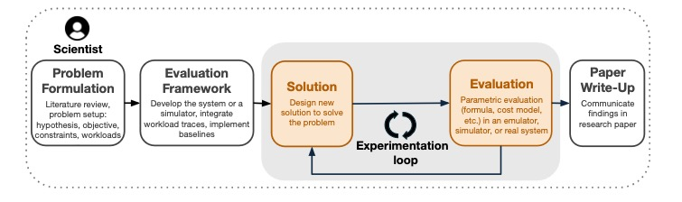

Figure 1. ADRS targets the Solution and Evaluation stages, not the whole research process.

This boundary matters. The paper is not claiming that problem selection, benchmark design, interpretation, or paper writing are solved. If anything, those parts become more important because the inner loop becomes cheaper.

## 3. Why this inner loop is tempting to automate

The paper motivates ADRS by arguing that algorithm design and evaluation consume a large fraction of systems research time. The exact number should not be overread; the survey is small. But the direction is plausible: a lot of research time is spent trying candidate methods and measuring whether they work.

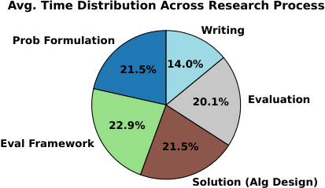

Figure 2. Algorithm Design and Evaluation together exceed 40% in the paper’s survey.

The hidden cost is important. The reported automation time does not fully capture human effort in refining prompts, constructing evaluators, debugging the setup, or deciding what the result means. This is where a critical reading should not become marketing.

## 4. The ADRS loop

Figure 3 is the central figure. A prompt generator packages the problem and context; a solution generator uses LLMs to produce candidates; an evaluator scores them; storage records the trajectory; and a solution selector chooses what to keep exploring.[P]

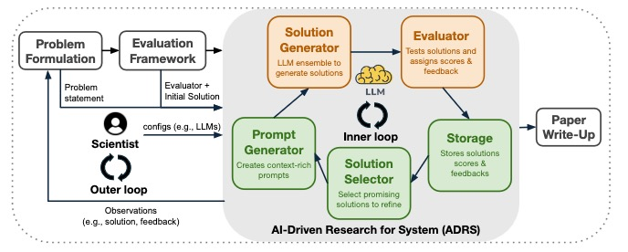

Figure 3. The ADRS loop is generate → evaluate → store → select, with optional human outer-loop guidance.

The most important object in this diagram is not the LLM. It is the evaluator. Without a good evaluator, the loop merely produces fluent-looking artifacts. With a good evaluator, the loop becomes a search process over executable solutions.

> If the evaluator is wrong, the loop does not become slower. It becomes confidently wrong faster.

## 5. The case studies: useful evidence, not a clean leaderboard

Table 1 reports 11 tasks across systems, databases, networking, and ML systems. It is useful because it shows that the ADRS pattern can be applied in several places. But I would not present it as a clean leaderboard: the paper notes that different students ran the studies in parallel with different configurations and without extensive ablations.[P]

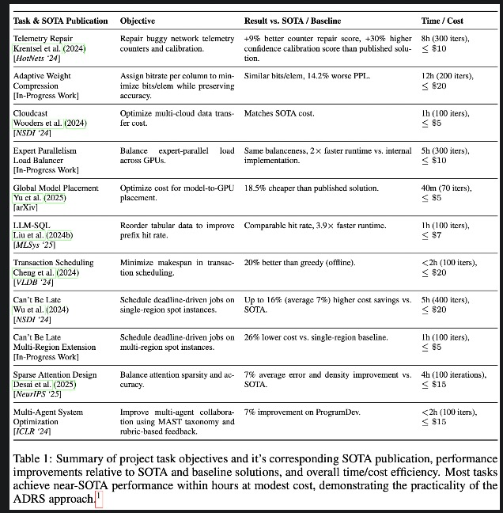

Table 1. Evidence map, not a universal proof that “AI beats SOTA.”

Before showing before/after code, each case needs a short problem statement. Otherwise the audience only sees code snippets without knowing what the algorithm is trying to optimize.

**Can’t Be Late: deadline scheduling with unreliable cheap spot instances**

The system wants to run jobs cheaply using spot instances, but spot instances can disappear. The policy must save cost while still meeting deadlines. The evaluator checks deadline validity and cost savings over traces.

**MoE Expert Placement: balance expert load across GPUs**

The system must place expert replicas across GPUs so that token load is balanced. The reported improvement comes from replacing Python-loop placement with tensorized zigzag placement.

**LLM-SQL: reorder table rows and fields for KV-cache reuse**

SQL-style analytics invokes LLM inference row by row. Reordering rows and fields can increase shared prompt prefixes, improving prefix cache hit rate. The evolved solution preserves hit rate while reducing reordering runtime.

**Transaction Scheduling: reorder transactions to reduce conflicts**

Transaction conflicts create bottlenecks. The goal is to schedule transactions so the makespan is minimized. This case is especially useful because online ADRS only rediscovers SOTA, while offline ADRS explores a new heavier search variant.

## 6. Case: Can’t Be Late

In the original setting, the Uniform Progress policy tracks whether the job is ahead or behind schedule. The evolved policy adds state: recent spot availability, stability classification, safety margins, buffer rebuilding, and selective waiting.[P]

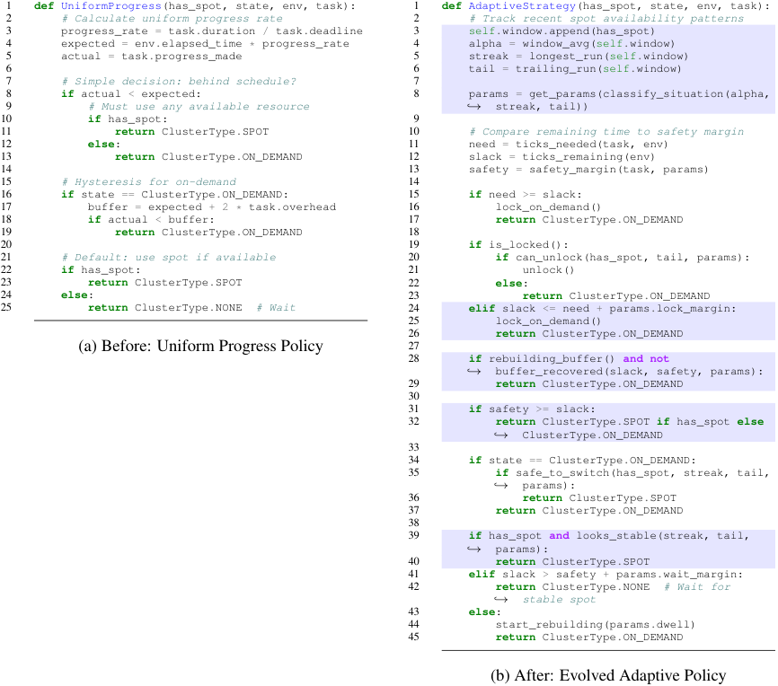

Figure 4. The evolved policy changes from fixed progress tracking to history-aware risk management.

This is a good example of policy evolution. The result is not just a faster implementation of the same formula. It adds a state machine around spot reliability: when spots are unstable, the policy can wait or fall back to on-demand; when spots are stable, it exploits them more aggressively.

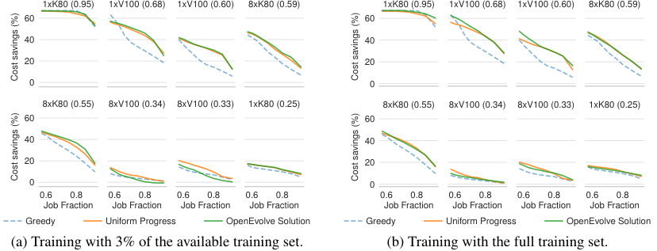

Cost-savings curves. Useful for discussing generalization and the danger of overfitting to a feedback subset.

## 7. Case: MoE expert placement

This case is closer to implementation-level systems optimization. The original logic is a greedy placement written with explicit loops. The evolved version discovers a tensorized “snake” pattern. It is still systems work because algorithm and implementation are entangled: the faster method is faster because it expresses the placement in a hardware/library-friendly form.

[figure not shown]

Figure 5. The evolved policy removes explicit loops and uses tensorized placement.

## 8. Case: LLM-SQL

This case is database-adjacent. The problem is not query optimization in the classical sense; it is layout/reordering for LLM inference over relational data. Each row may trigger an LLM call, so the system wants adjacent prompts to share more prefix tokens. The objective is a tradeoff: high prefix hit rate and low reordering runtime.

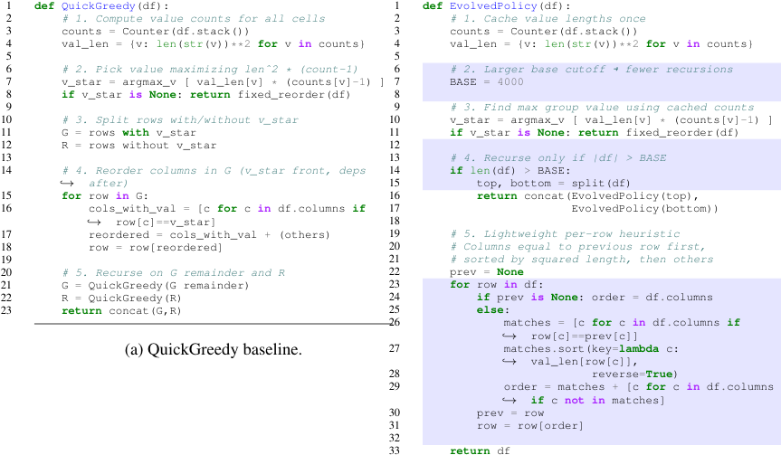

Figure 6. The evolved policy reduces repeated counting and recursion while preserving similar prefix hit rate.

This is a useful place to ask whether ADRS is discovering a new method or simply optimizing code. The answer is mixed: it introduces a heuristic for preserving prefix continuity, but much of the gain also comes from removing obvious overhead. That ambiguity is normal in systems work.

## 9. Deep dive: Transaction Scheduling

This is the case I would spend the most time on. The problem is easy to explain to a database audience: transactions conflict on shared data; a better schedule reduces conflict and lowers makespan.

The online setting is strict: the order is fixed once scheduled, committed transactions cannot be rolled back, the algorithm is constrained to linear time, and full read/write operations are not known in advance. Under those constraints, OpenEvolve rediscovers SMF, and the paper explicitly notes possible training contamination.[P]

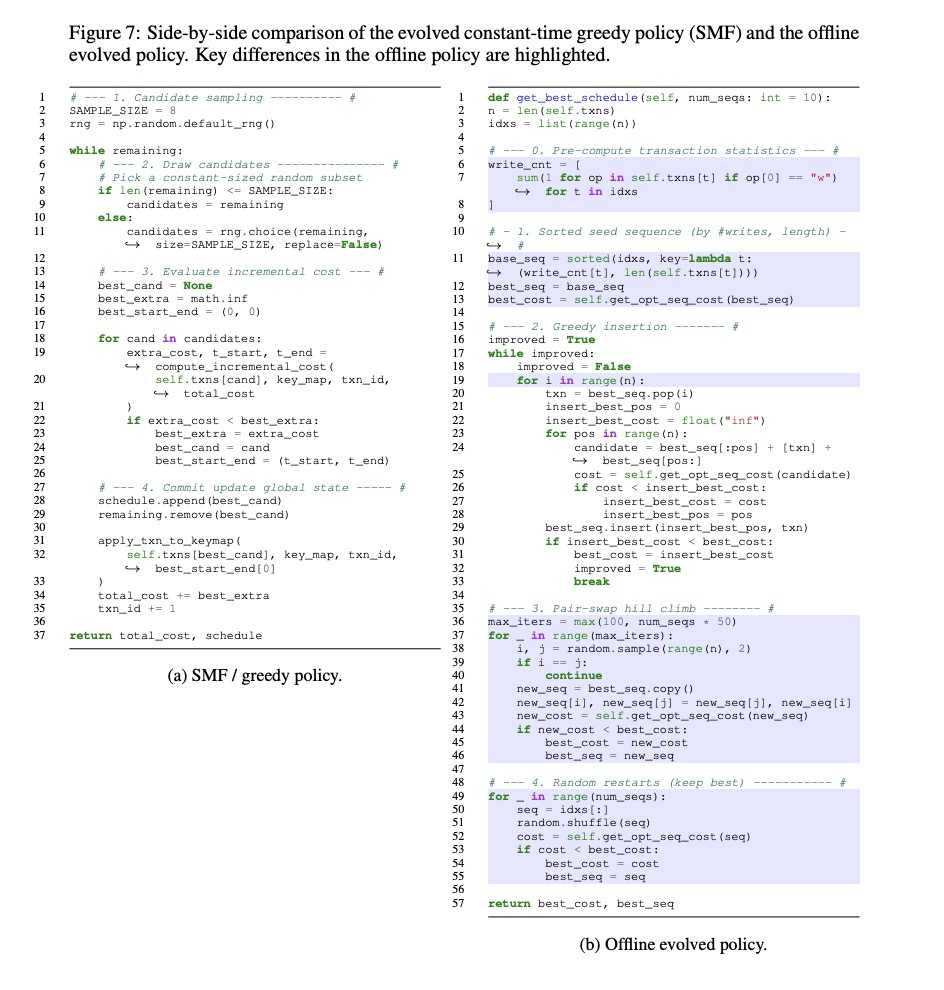

Figure 7. Online SMF on the left; offline evolved policy on the right. The right side becomes heavier because the constraints change.

The offline setting is more interesting. Once online constraints are removed, ADRS finds a heavier algorithm: it computes simple transaction features, seeds the schedule by writes and length, tries greedy insertion into many positions, performs pair-swap hill climbing, and uses random restarts.

> The lesson is not “AI magically beats SOTA.” The lesson is that ADRS can rapidly explore a changed design space when the evaluator is clear.

## 10. Section 6: early best practices and failure modes

This is one of the strongest parts of the paper. The authors classify runtime errors, search failures, and algorithm failures. The last category is the most dangerous: the program runs, but it overfits, ignores constraints, or exploits the evaluator.

The best-practice section can be summarized as four engineering rules: write structured problem specifications, use model ensembles carefully, prevent overfitting and reward hacking in the evaluator, and maintain solution diversity rather than selecting only the current top score.

Brooker emphasizes that overfitting and reward hacking are not new to systems research. Benchmarks have long been overfit; AI simply increases the throughput of this failure mode.[B]

> A bad evaluator does not merely produce noisy results. It creates a target for the model to exploit.

## 11. Section 7: limits, explained through one example

I would avoid presenting Section 7 as a simplistic green/red table. A better way is to use one contrast.

Suppose the task is to improve a local scheduling policy inside a simulator. The candidate modifies one function. The simulator can run hundreds of traces quickly. Correctness is simple: all jobs must be scheduled, all deadlines must be met, and the cost metric is measurable. This is a good ADRS target.

Now suppose the task is to redesign a distributed consensus protocol across many interacting modules. The candidate may touch state management, network behavior, failure detection, persistence, and recovery. The verifier is no longer a simple benchmark; semantic equivalence and safety become hard to prove. This is a poor ADRS target unless the evaluation and formal constraints are much stronger.

> ADRS works best when the search space is local, the evaluator is reliable, and the evaluation is cheap enough to repeat.

## 12. Connecting this to my own GPU byte-plane research

My current workflow is not a fully automated ADRS system, but it has similar ingredients. I use issues and agents to decompose work; correctness gates and benchmarks reject bad variants; profiling results help decide whether an apparent improvement has a real mechanism.

Two recent project commits make this concrete. One commit cleans up the paper-facing figure packet and tightens captions, source snapshots, and claim boundaries for Issue #94.[G1] Another commit adds a workshop submission draft that explicitly scopes the paper as a warm, device-resident H200 operator study, with four tested true-quasi-global scientific fields and a narrow k=2 shallow-depth headline.[G2]

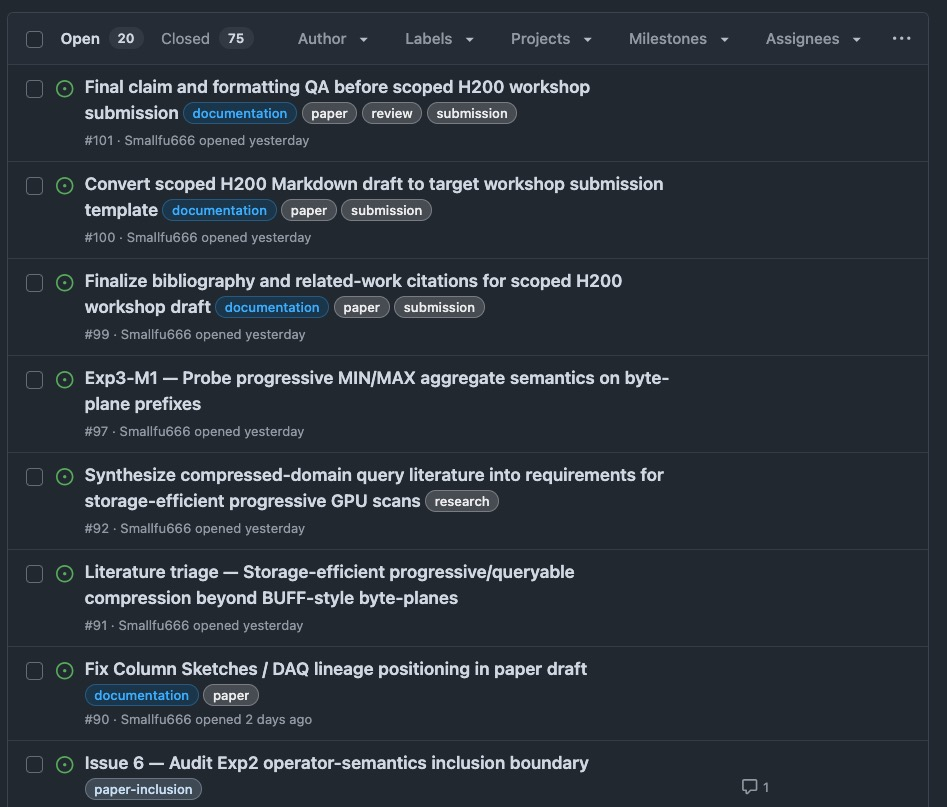

A practical outer loop: issues encode tasks, constraints, and review gates. This is not fully ADRS, but it is a human-steered search workflow.

The right mapping is not “let AI decide the research.” The safer mapping is: let AI search within a fixed semantic boundary, then force every candidate through explicit gates.

| Layer | What the gate should check | Why |
| --- | --- | --- |
| Correctness | COUNT matches encoded CPU oracle; SUM bounds hold | Prevents fake speedups |
| Performance | Median throughput across fixed k/selectivity/dataset cases | Prevents cherry-picking |
| Generalization | Uniform, heavy-tailed, zipfian, and scientific datasets | Prevents benchmark overfitting |
| Mechanism | NCU evidence: traffic, stalls, occupancy, eligible warps | Explains why a speedup exists |
| Claim relevance | Does the result support the paper’s actual thesis? | Prevents meaningless number chasing |

> Do not ask AI whether the kernel is better. Build gates that make lying expensive.

## 13. How should we coexist with AI research agents?

Murat’s critique is useful because it shifts the discussion away from raw benchmark gains. He argues that LLMs provide breadth, but research demands depth; they can produce many variants quickly, but they do not automatically provide taste, clarity, or insight.[M1]

He also frames LLMs as potentially useful collaborators rather than autonomous researchers. One short phrase captures the hierarchy: “Good collaborators > No collaborators > Bad collaborators.”[M1] The condition is that the work must be bite-sized, bounded, and judged by a human who still understands the system.

His separate PhD-process essay is the right ending frame. The hidden curriculum of research is not only producing papers; it is developing curiosity/taste, clarity, craft, community, and courage.[M2] Those are exactly the skills that become more important when solution generation becomes cheap.

> Use agents to reduce friction. Do not use them to avoid thinking.

## 14. Publication pressure: more results, or more insight?

Brooker’s critique gives the sharpest social question. If AI makes optimization cheap, the community could get higher-quality work with less effort, but it could also get more meaningless hill climbing. His compact warning is “100x more papers and 10x less insight.”[B]

This is not only an AI problem. It is a systems-research incentive problem that AI can amplify. If program committees reward benchmark climbing without mechanism, agents will climb benchmarks. If the community rewards clean problem formulation, credible evaluation, and insight, agents can become useful assistants.

## 15. Final takeaway

The strongest reading of this paper is not that AI will replace systems researchers. The stronger reading is that the job of the systems researcher becomes more sharply defined.

If solution generation becomes cheap, the scarce skills are problem selection, evaluator construction, benchmark skepticism, and insight distillation. AI can climb hills faster. The researcher still has to decide which hill is worth climbing, and whether the altitude meter is real.

## References and cited sources

1. [P] Cheng et al., [*Barbarians at the Gate: How AI is Upending Systems Research*](https://arxiv.org/abs/2510.06189), 2025.
2. [M1] Murat Demirbas, [“Barbarians at the Gate: How AI is Upending Systems Research”](https://muratbuffalo.blogspot.com/2025/10/barbarians-at-gate-how-ai-is-upending.html), 2025.
3. [M2] Murat Demirbas, [“Academic chat: On PhD”](https://muratbuffalo.blogspot.com/2025/10/academic-chat-on-phd.html), 2025.
4. [B] Marc Brooker, [“Is Systems Research Really Just About Making Numbers Bigger?”](https://brooker.co.za/blog/2025/10/12/barbarians.html), 2025.
5. [G0] Smallfu666, gpu-byteplane-scan-experiments, GitHub repository.
6. [G1] Commit [fce2739](https://github.com/Smallfu666/gpu-byteplane-scan-experiments/commit/fce27399a7e5d4143a4188d21f0d245a59792aa9), figure-packet cleanup and Issue #94 review feedback.
7. [G2] Commit [8249e14](https://github.com/Smallfu666/gpu-byteplane-scan-experiments/commit/8249e141b6d6c0d5945afc1a6da4891040bcf798), workshop submission draft for Issue #96.